# Homework 1 - EDS 223

Author

Lauren Puffer

## Introduction

The purpose of this analysis is to get a visual understanding of the relationship between air pollution and socioeconomic status in San Joaquin County in California.

## Load Packages

For this analysis, we will be using the ‘tmap’ package to generate maps with data pulled from the ‘Environmental Justice Screening and Mapping Tool.’ We will also be using ‘here’ and ‘tidyverse’ for file management and workflow optimization.

```r
library(tmap)
library(here)
library(tidyverse)
library(sf) # allows us to bring in shape files for mapping
library(stars) # for raster and vector data
library(tigris) # for bringing in map of Arizona and counties
library(viridisLite) # colorblind friendly palettes
```

## Shape files & EJ Screen data

In order to properly display our data, we must first bring in the shape files of the areas we wish to look at, as well as the data itself. For the scale of this project, we will use the tigris package to obtain our shape file of San Joaquin county. Provided is the code to scale this analysis up to the state level, or down to the census tract. We will be constructing our maps at the county level.

```r
# make sure you are downloading shape files from 'tigris'
options(tigris_class = "sf")

# bring in shape file of California counties
ca_counties <- counties(state = "CA", progress_bar = FALSE)

# bring in census tracts for California
ca_tracts <- tracts(state = "CA", progress_bar = FALSE)

# bring in just San Joaquin county
sanjoaquin_shape <- ca_counties |>
  filter(NAME == "San Joaquin")

# read in geodatabase of EJScreen data at the Census Block Group level
ejscreen <- st_read(here::here("data", "ejscreen","EJSCREEN_2023_BG_StatePct_with_AS_CNMI_GU_VI.gdb"))
# filter for data from California
california <- ejscreen |>
  filter(ST_ABBREV == "CA")

# filter data from San Joaquin county
sanjoaquin <- california |>
  filter(CNTY_NAME %in% c("San Joaquin County"))
```

## Visualize data

In order to explore the relationship between demographic index (an aggregated score of percent low income and percent people of color) and PM 2.5 in average micrograms per liter per year. People of color were considered to be anyone who listed a race other than white in the census. Low income households included anyone who was less than or equal to the federal poverty level.

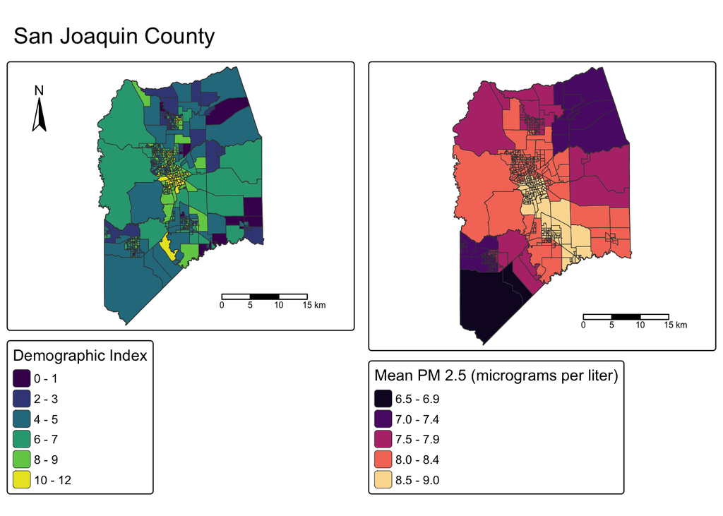

```r
# make maps static
tmap_mode("plot")

# make a map of Demographic Index in San Joaquin County
sanjoaquin_demo <- tm_shape(sanjoaquin_shape, bbox = sanjoaquin) +
      tm_polygons()+
    tm_shape(sanjoaquin)+
      tm_polygons(fill = "B_DEMOGIDX_2",
                  lwd = 0.5,
                  fill.scale = tm_scale(values = "viridis"),
                  fill.legend = tm_legend(title = "Demographic Index"))+
    tm_compass(type = "arrow",
               position = c("left", "top"),
               size = 2) +
    tm_scalebar()+
      tm_title("San Joaquin County")


# make a map of PM 25 in San Joaquin County
sanjoaquin_pm25 <- tm_shape(sanjoaquin_shape, bbox = sanjoaquin) +
      tm_polygons()+
    tm_shape(sanjoaquin)+
      tm_polygons(fill = "PM25",
                  lwd = 0.5,
                  fill.scale = tm_scale(values = "magma"),
                  fill.legend = tm_legend(title = "Mean PM 2.5 (micrograms per liter)"))+
tm_scalebar(position = c("right", "bottom")) +
        tm_title(" ")

# arrange side-by-side
tmap_arrange(sanjoaquin_demo, sanjoaquin_pm25, ncol = 2)
```

## Map interpretation

When we consider that many residents in these areas have middle to high demographic index scores, we can begin to examine the relationship between air pollution and lower socioeconomic status. This is important to consider when evaluating property costs, the location of housing, and the environmental hazards that may surround it. People of lower socioeconomic status tend to live in more affordable areas, and more affordable areas are often associated with greater environmental risks. This is, in part, because the housing market does not account for environmental discrepancies, forcing those of lower socioeconomic status to tolerate worse environmental conditions and greater health hazards.

## Data citation

U.S. Environmental Protection Agency (EPA), 2023. EJScreen Technical Documentation.

Link to EJ Screen: https://pedp-ejscreen.azurewebsites.net/

Particulate Matter (PM) 2.5 and Ozone values are derived from 2019 source data from EPA’s Office of Air Quality Planning and Standards (OAQPS), Non-attainment areas (NAA).

Demographic Index data comes from [US Census American Community Survey Data via FTP](https://www.census.gov/programs-surveys/acs/data/data-via-ftp.html)